# report

2025-06-23

```r
library(knitr)
library(tidyverse)
```

```r
library(broom)
library(htmltools)
library(dplyr)
library(tidyr)
library(stringr)
library(dplyr)
library(ggplot2)
library(ggcorrplot)
library(Metrics)
library(reshape2)
library(rsample)
library(tidymodels)
```

Data Loading and Preprocessing:

This section loads three datasets related to school background, test results, and student-reported atmosphere. It performs several preprocessing steps:

Combines socio-economic indicators into a single socio_economy variable.

Merges student test results with background and atmosphere data.

Reshapes student response data (where var_id starts with “T”) into a wide format for analysis.

Filters out columns with too many missing values (less than 80% completeness).

Focuses the dataset on Math subject results only.

```r
background_df = read.csv("data\\school_background_info.csv", fileEncoding = "Windows-1255")
results_df = read.csv("data\\school_results.csv", fileEncoding = "Windows-1255")
atmosphere_df = read.csv("data\\school_temperament.csv", fileEncoding = "Windows-1255")

# Step 1: Create socio_economy variable by filling missing values
background_df <- background_df %>%
  mutate(socio_economy = coalesce(ses_mosad_cat_yh, ses_mosad_cat_e))

# Step 2: Merge results with background data on 'semel_mosad'
merged_df <- results_df %>%
  inner_join(background_df, by = "semel_mosad")

# Step 3: Filter atmosphere_df to rows where var_id starts with "T", T = students answers
df_T_only <- atmosphere_df %>%
  filter(str_starts(var_id, "T"))

# Step 4: Pivot to wide format: each var_id becomes a column, with values filled in
students_df <- df_T_only %>%
  pivot_wider(
    id_cols = c(year, semel_mosad),
    names_from = var_id,
    values_from = value,
    values_fn = mean
  )


# Step 5: Merge students_df into merged_df on year and semel_mosad
merged_df <- merged_df %>%
  inner_join(students_df, by = c("year", "semel_mosad"))

# Step 6: Keep only columns with more than 80% non-null values
non_null_counts <- colSums(!is.na(merged_df))
columns_to_keep <- names(non_null_counts[non_null_counts / nrow(merged_df) > 0.8])

# Step 9: Filter merged_df to include only those columns
filtered_df <- merged_df[, columns_to_keep]
filtered_df = filtered_df %>% select(-c("ses_mosad_cat_e", "ses_mosad_cat_yh"))
clean_df <- filtered_df %>% drop_na()

# Filter data for Math subject only
math_df <- clean_df %>% filter(subject_id == "M")

# Convert score column to numeric (in case it's character or factor)
math_df <- math_df %>%
  mutate(score = as.numeric(score))
# Keep only numeric columns and rows with non-missing score
numeric_df <- math_df %>%
  select(where(is.numeric)) %>%
  filter(!is.na(score))
```

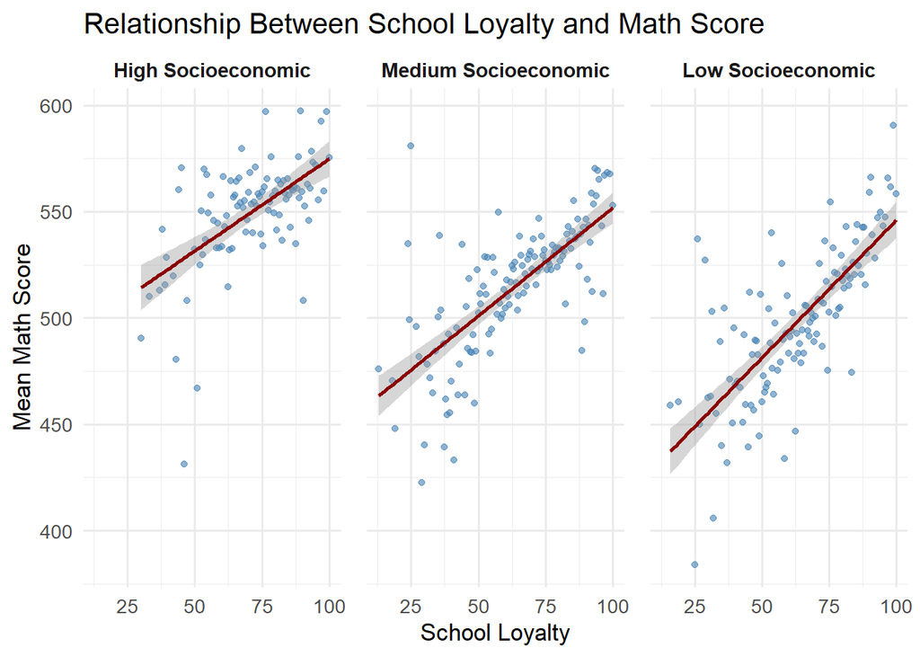

```r
# Analyze the relationship between school loyalty and math score,
# segmented by socioeconomic status. Calculates group means and
# visualizes trends using faceted scatter plots with confidence intervals.

# Clean the 'score' column: remove whitespace and convert to numeric
clean_df <- clean_df %>%
  mutate(
    score = as.numeric(trimws(score))  # remove spaces and convert to numeric
  )
# Group by School Loyalty (T_1005_Rd) and Socioeconomic group, then calculate mean score
loyalty_score_summary <- clean_df %>%
  filter(!is.na(T_1005_Rd), !is.na(score)) %>%
  group_by(T_1005_Rd, socio_economy) %>%
  summarise(mean_score = mean(score), .groups = "drop") %>%
  arrange(T_1005_Rd)

# Define readable labels
socio_labels <- c(
  "1" = "High Socioeconomic",
  "2" = "Medium Socioeconomic",
  "3" = "Low Socioeconomic"
)

# Add a column with labeled socioeconomic group for faceting
loyalty_score_summary <- loyalty_score_summary %>%
  mutate(
    socio_label = socio_labels[as.character(socio_economy)],
    socio_label = factor(socio_label, levels = c(
      "High Socioeconomic",
      "Medium Socioeconomic",
      "Low Socioeconomic"
    ))
  )


# Plot the relationship between School Loyalty and Mean Math Score, faceted by socioeconomic group
ggplot(loyalty_score_summary, aes(x = T_1005_Rd, y = mean_score)) +
  geom_point(alpha = 0.6, color = "steelblue") +
  geom_smooth(method = "lm", se = TRUE, color = "darkred") +
  facet_wrap(~ socio_label, scales = "fixed") +
  labs(
    title = "Relationship Between School Loyalty and Math Score",
    x = "School Loyalty",
    y = "Mean Math Score"
  ) +
  theme_minimal(base_size = 13) +
  theme(
    panel.spacing = unit(1, "lines"),
    strip.text = element_text(face = "bold", size = 11)
  )
```

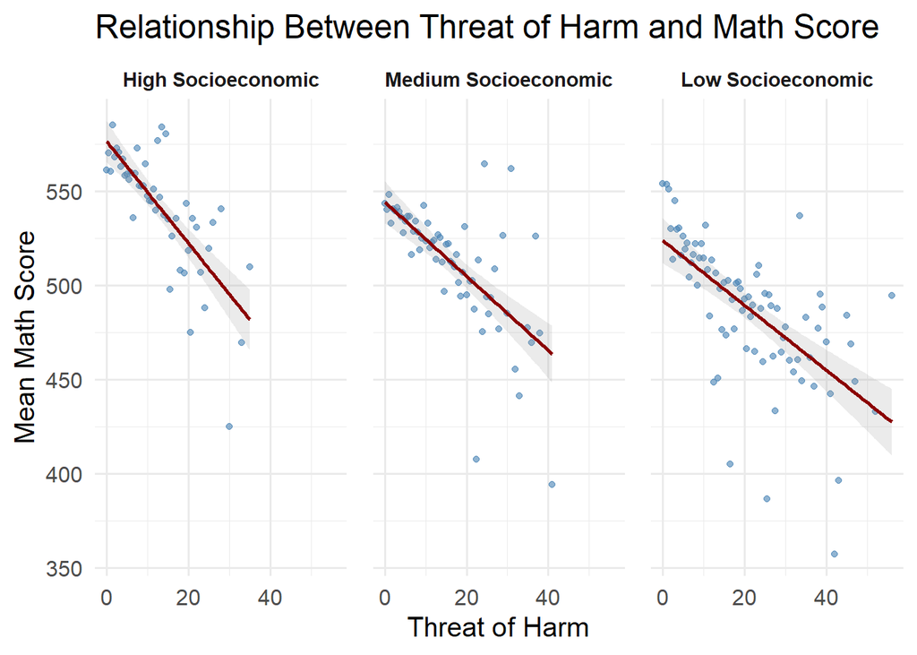

```r
# Analyze the relationship between perceived threat of harm and math score,
# grouped by socioeconomic status. Visualized using faceted scatter plots
# with linear trends and confidence intervals.

# Group and summarize by threat of harm and socio_economy
threat_score_summary <- clean_df %>%
  filter(!is.na(score), !is.na(T_1036_Di), !is.na(socio_economy)) %>%
  group_by(T_1036_Di, socio_economy) %>%
  summarise(mean_score = mean(score), .groups = "drop") %>%
  arrange(T_1036_Di)

# Add a column with labeled socioeconomic group for faceting
threat_score_summary <- threat_score_summary %>%
  mutate(
    socio_label = socio_labels[as.character(socio_economy)],
    socio_label = factor(socio_label, levels = c(
      "High Socioeconomic",
      "Medium Socioeconomic",
      "Low Socioeconomic"
    ))
  )

# Plot with confidence interval
ggplot(threat_score_summary, aes(x = T_1036_Di, y = mean_score)) +
  geom_point(alpha = 0.6, color = "steelblue") +
  geom_smooth(method = "lm", se = TRUE, color = "darkred",alpha = 0.2) +
  facet_wrap(~ socio_label, scales = "fixed") +
  labs(
    title = "Relationship Between Threat of Harm and Math Score",
    x = "Threat of Harm",
    y = "Mean Math Score"
  ) +
  theme_minimal(base_size = 15) +
  theme(
    panel.spacing = unit(1, "lines"),
    strip.text = element_text(face = "bold", size = 11)
  )
```

This chunk creates summary indices for school climate by averaging related survey questions, then standardizes these indices and student scores within each socio-economic group and year to enable fair comparisons across schools.

```r
# Define categories of survey questions to build composite indices
category_vars <- list(
  Violence_Index = c("T_Violence", "T_1032_Di", "T_1033_Di", "T_1034_Di", "T_1035_Di",
                     "T_1036_Di", "T_1037_Di", "T_1038_Di", "T_1039_Di", "T_1040_Di"),
  EffortViolence_Index = c("T_EffortViolence", "T_1009_Di", "T_1013_Di", "T_1016_Di"),
  Caring_Index = c("T_Caring", "T_1003_Di", "T_1007_Di", "T_1011_Di", "T_1018_Di"),
  Atmosphere_Index = c("T_Atmosphere", "T_1001_Di", "T_1010_Rd", "T_1012_Rd", "T_1030_Rd"),
  Satisfaction_Index = c("T_Satisfaction", "T_1005_Rd", "T_1017_Di", "T_1056_Di"),
  Feedback_Index = c("T_Feedback", "T_1014_Di", "T_1050_Di", "T_1053_Di", "T_1054_Di", "T_1055_Di", "T_1059_Di")
)

# Calculate average index scores for each row (school) based on defined question
climate_df <- math_df %>%
  rowwise() %>%
  mutate(
    Violence_Index = mean(c_across(all_of(category_vars$Violence_Index)), na.rm = TRUE),
    EffortViolence_Index = mean(c_across(all_of(category_vars$EffortViolence_Index)), na.rm = TRUE),
    Caring_Index = mean(c_across(all_of(category_vars$Caring_Index)), na.rm = TRUE),
    Atmosphere_Index = mean(c_across(all_of(category_vars$Atmosphere_Index)), na.rm = TRUE),
    Satisfaction_Index = mean(c_across(all_of(category_vars$Satisfaction_Index)), na.rm = TRUE),
    Feedback_Index = mean(c_across(all_of(category_vars$Feedback_Index)), na.rm = TRUE)
  ) %>%
  ungroup() %>%
  # Keep only the new index columns
  select(Violence_Index, EffortViolence_Index, Caring_Index,
         Atmosphere_Index, Satisfaction_Index, Feedback_Index)

# Clean the math_df by:
# - Removing all raw student survey response columns (those starting with "T_")
# - Appending the previously calculated climate indices for each school
math_df_cleaned <- math_df %>%
  select(-matches("^T_")) %>%
  bind_cols(climate_df)



# Define the numeric variables that will be standardized (z-scored)
vars_to_scale <- c(
  "score", "Violence_Index", "EffortViolence_Index",
  "Caring_Index", "Atmosphere_Index",
  "Satisfaction_Index",
  "Feedback_Index"
)

# Define columns to keep
columns_to_keep <- c(
  "score",
  "Violence_Index",
  "EffortViolence_Index",
  "Caring_Index",
  "Atmosphere_Index",
  "Satisfaction_Index",
  "Feedback_Index"
)

# Normalize each variable (z-score) within each year and socio-economic group
# This ensures fair comparison across time and demographic contexts
math_df_scaled <- math_df_cleaned %>%
  group_by(year, socio_economy) %>%
  mutate(across(all_of(vars_to_scale), ~ (.-mean(., na.rm=TRUE)) / sd(., na.rm=TRUE))) %>%
  ungroup()

# Remove any rows that still contain missing values after normalization
math_df_scaled <- na.omit(math_df_scaled)
```

This chunk calculates all pairwise correlations between the score and climate indices, then visualizes them using a heatmap.

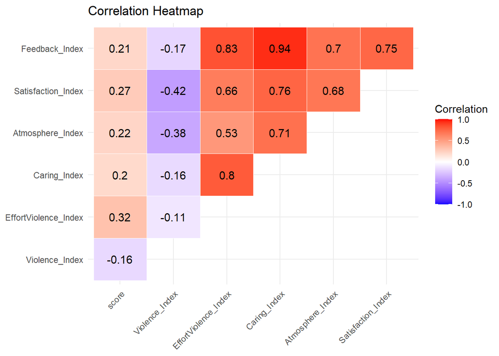

```r
# Select relevant columns and remove NAs
cor_data <- math_df_scaled %>%
  select(all_of(columns_to_keep)) %>%
  drop_na()

# Compute correlation matrix
cor_matrix <- cor(cor_data, use = "complete.obs")

# Melt matrix to long format
cor_long <- melt(cor_matrix, varnames = c("Var1", "Var2"))

# Keep only lower triangle
cor_long <- cor_long %>%
  mutate(order1 = as.numeric(factor(Var1, levels = colnames(cor_matrix))),
         order2 = as.numeric(factor(Var2, levels = colnames(cor_matrix)))) %>%
  filter(order1 > order2)

# Plot heatmap
ggplot(cor_long, aes(x = Var2, y = Var1, fill = value)) +
  geom_tile(color = "white") +
  geom_text(aes(label = round(value, 2)), size = 4) +
  scale_fill_gradient2(low = "blue", high = "red", mid = "white",
                       midpoint = 0, limit = c(-1, 1), name = "Correlation") +
  theme_minimal() +
  labs(
    title = "Correlation Heatmap",
    x = NULL,
    y = NULL
  ) +
  theme(axis.text.x = element_text(angle = 45, hjust = 1))
```

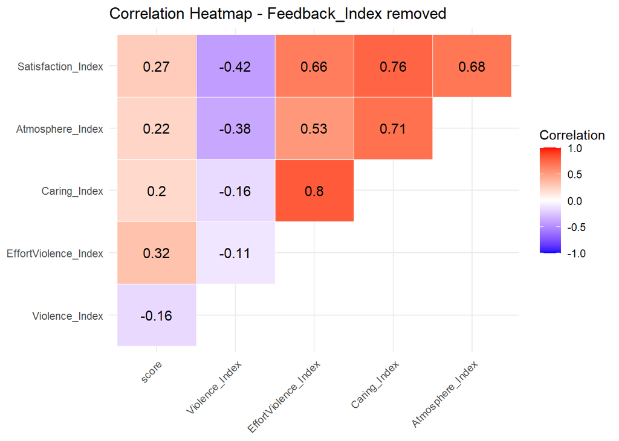

```r
# Define columns to keep
columns_to_keep <- c(
  "score",
  "Violence_Index",
  "EffortViolence_Index",
  "Caring_Index",
  "Atmosphere_Index",
  "Satisfaction_Index"
)

# Select relevant columns and remove NAs
cor_data <- math_df_scaled %>%
  select(all_of(columns_to_keep)) %>%
  drop_na()

# Compute correlation matrix
cor_matrix <- cor(cor_data, use = "complete.obs")

# Melt matrix to long format
cor_long <- melt(cor_matrix, varnames = c("Var1", "Var2"))

# Keep only lower triangle
cor_long <- cor_long %>%
  mutate(order1 = as.numeric(factor(Var1, levels = colnames(cor_matrix))),
         order2 = as.numeric(factor(Var2, levels = colnames(cor_matrix)))) %>%
  filter(order1 > order2)

# Plot heatmap
ggplot(cor_long, aes(x = Var2, y = Var1, fill = value)) +
  geom_tile(color = "white") +
  geom_text(aes(label = round(value, 2)), size = 4) +
  scale_fill_gradient2(low = "blue", high = "red", mid = "white",
                       midpoint = 0, limit = c(-1, 1), name = "Correlation") +
  theme_minimal() +
  labs(
    title = "Correlation Heatmap - Feedback_Index removed",
    x = NULL,
    y = NULL
  ) +
  theme(axis.text.x = element_text(angle = 45, hjust = 1))
```

```r
# Split into three separate data frames by socio_economy
low_df_scaled  <- math_df_scaled %>% filter(socio_economy == "3") %>% select(all_of(columns_to_keep))
mid_df_scaled  <- math_df_scaled %>% filter(socio_economy == "2") %>% select(all_of(columns_to_keep))
high_df_scaled <- math_df_scaled %>% filter(socio_economy == "1") %>% select(all_of(columns_to_keep))
```

This chunk defines a function to train and evaluate a linear regression model using k-fold cross-validation. It uses a recipe-based workflow and returns performance metrics: RMSE, R², and MAE.

```r
cv_train_and_evaluate <- function(data, folds = 5) {
  set.seed(123)

  # Cross-validation folds
  cv_folds <- vfold_cv(data, v = folds)

  # Recipe
  recipe_spec <- recipe(score ~ ., data = data)

  # Linear model
  lm_model <- linear_reg() %>% set_engine("lm")

  # Workflow
  model_workflow <- workflow() %>%
    add_recipe(recipe_spec) %>%
    add_model(lm_model)

  # Fit with correct metric functions from yardstick
  results <- fit_resamples(
    model_workflow,
    resamples = cv_folds,
    metrics = yardstick::metric_set(yardstick::rmse, yardstick::rsq, yardstick::mae),
    control = control_resamples(save_pred = TRUE)
  )

  # Collect performance metrics
  metrics <- collect_metrics(results)
  return(metrics)
}
```

```r
# Run for each group
low_metrics  <- cv_train_and_evaluate(low_df_scaled)  %>% mutate(group = "Low")
mid_metrics  <- cv_train_and_evaluate(mid_df_scaled)  %>% mutate(group = "Mid")
high_metrics <- cv_train_and_evaluate(high_df_scaled) %>% mutate(group = "High")

# Combine results
cv_results <- bind_rows(low_metrics, mid_metrics, high_metrics)

# View results
cv_results
```

```
## # A tibble: 9 × 7
##   .metric .estimator  mean     n std_err .config              group
##   <chr>   <chr>      <dbl> <int>   <dbl> <chr>                <chr>
## 1 mae     standard   0.722     5 0.00428 Preprocessor1_Model1 Low
## 2 rmse    standard   0.904     5 0.00609 Preprocessor1_Model1 Low
## 3 rsq     standard   0.183     5 0.0158  Preprocessor1_Model1 Low
## 4 mae     standard   0.707     5 0.0135  Preprocessor1_Model1 Mid
## 5 rmse    standard   0.912     5 0.0283  Preprocessor1_Model1 Mid
## 6 rsq     standard   0.167     5 0.0164  Preprocessor1_Model1 Mid
## 7 mae     standard   0.700     5 0.0205  Preprocessor1_Model1 High
## 8 rmse    standard   0.941     5 0.0335  Preprocessor1_Model1 High
## 9 rsq     standard   0.107     5 0.00736 Preprocessor1_Model1 High
```

This chunk defines a function that uses bootstrap resampling to estimate the mean and 95% confidence intervals of linear model coefficients, providing a robust summary of their stability and variability.

```r
bootstrap_coefficients <- function(data, n_boot = 1000, seed = 123) {
  set.seed(seed)

  # Get formula and variables
  model_formula <- score ~ .

  # Bootstrap resamples
  boot_resamples <- bootstraps(data, times = n_boot)

  # Fit linear model and extract coefficients for each bootstrap sample
  coef_results <- boot_resamples %>%
    mutate(
      model = map(splits, ~ lm(model_formula, data = analysis(.x))),
      coefs = map(model, tidy)
    ) %>%
    select(coefs) %>%
    unnest(coefs)

  # Summarize: mean and 95% CI
  summary <- coef_results %>%
    group_by(term) %>%
    summarise(
      Mean = mean(estimate, na.rm = TRUE),
      Lower_CI = quantile(estimate, 0.025, na.rm = TRUE),
      Upper_CI = quantile(estimate, 0.975, na.rm = TRUE),
      .groups = "drop"
    )

  return(summary)
}
```

```r
low_bootstrap_summary <- bootstrap_coefficients(low_df_scaled)
mid_bootstrap_summary <- bootstrap_coefficients(mid_df_scaled)
high_bootstrap_summary <- bootstrap_coefficients(high_df_scaled)
```

```r
plot_bootstrap_coefs <- function(coef_summary, group_label = "Group") {
  # Select top 10 variables by absolute mean
  top_coefs <- coef_summary %>%
    filter(term != "(Intercept)") %>%
    arrange(desc(abs(Mean))) %>%
    slice(1:10) %>%
    mutate(
      term = fct_reorder(term, Mean),
      hjust_val = ifelse(Mean > 0, 0, 1),
      nudge_x = ifelse(Mean > 0, 0.02, -0.02)
    )

  ggplot(top_coefs, aes(x = Mean, y = term, fill = Mean)) +
    geom_col() +
    geom_errorbar(aes(xmin = Lower_CI, xmax = Upper_CI), width = 0.2) +
    geom_text(
      aes(label = round(Mean, 2)),
      hjust = top_coefs$hjust_val,
      nudge_x = top_coefs$nudge_x,
      nudge_y = 0.3,
      size = 3.5,
      color = "black"
    ) +
    scale_fill_gradient2(
      low = "indianred3",
      mid = "white",
      high = "mediumpurple3",
      midpoint = 0
    ) +
    labs(
      title = paste("Linear Regression Coefficients (95% CI) –", group_label),
      x = "Bootstrap Coefficient",
      y = "Variable"
    ) +
    theme_minimal() +
    theme(
      legend.position = "none",
      axis.text.y = element_text(size = 14),  # Y-axis (variable names)
      axis.text.x = element_text(size = 12),  # X-axis (tick numbers)
      axis.title = element_text(size = 14),   # Axis titles
      plot.title = element_text(size = 12, face = "bold")  # Plot title
    )
}
```

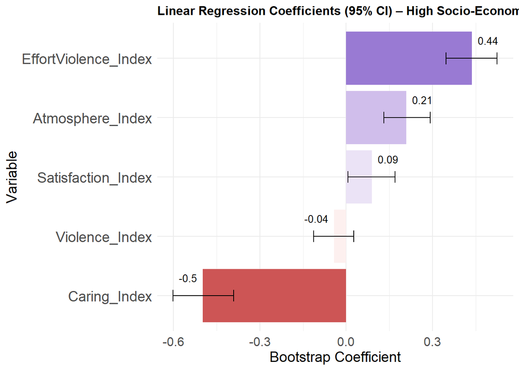

```r
plot_bootstrap_coefs(high_bootstrap_summary, group_label = "High Socio-Economic")
```

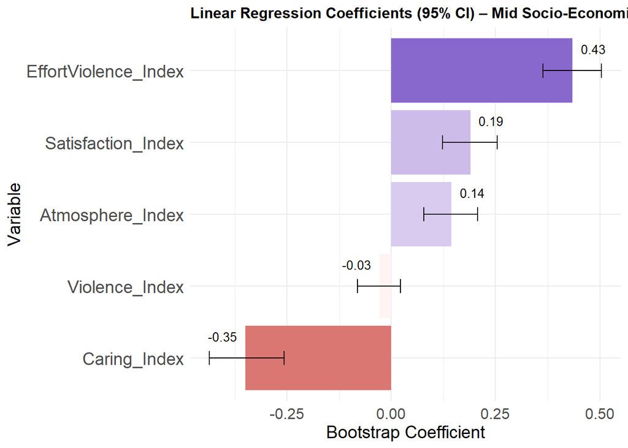

```r
plot_bootstrap_coefs(mid_bootstrap_summary, group_label = "Mid Socio-Economic")
```

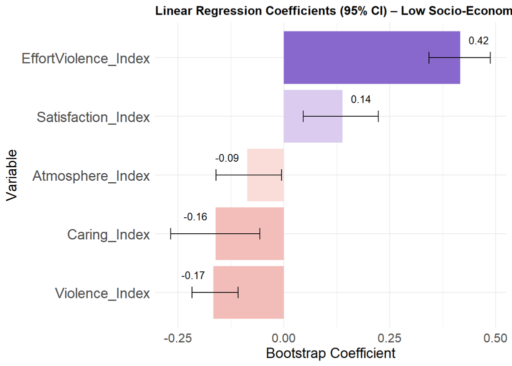

```r
plot_bootstrap_coefs(low_bootstrap_summary, group_label = "Low Socio-Economic")
```

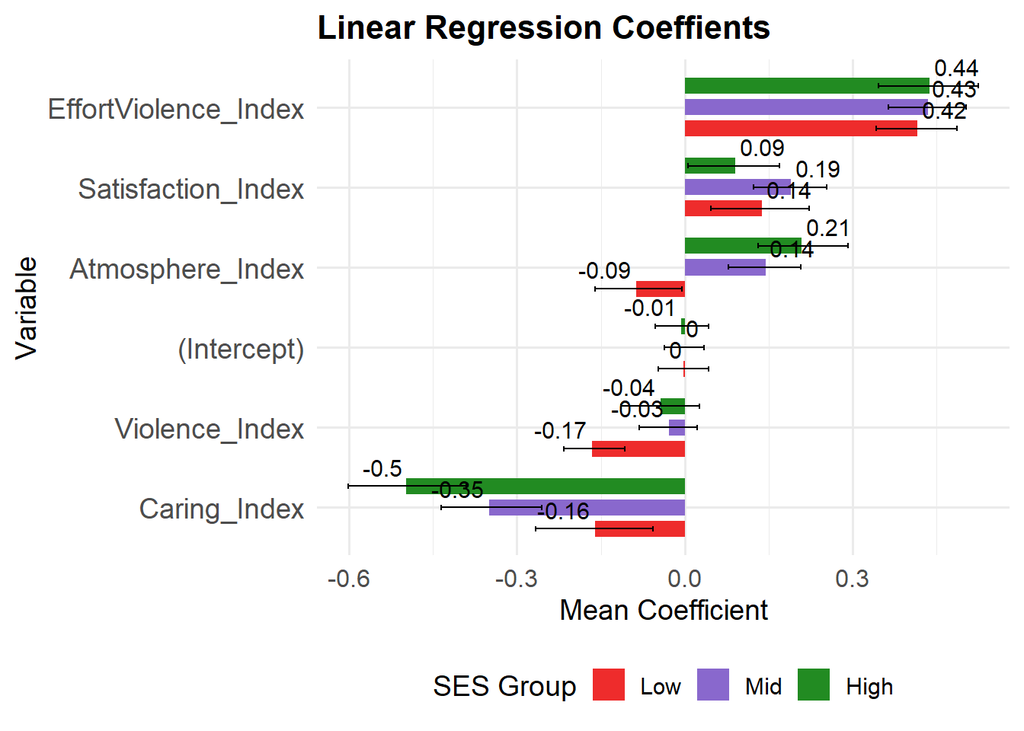

```r
# Add SES_Group to each summary
low_summary <- low_bootstrap_summary %>% mutate(SES_Group = "Low")
mid_summary <- mid_bootstrap_summary %>% mutate(SES_Group = "Mid")
high_summary <- high_bootstrap_summary %>% mutate(SES_Group = "High")

# Combine all into one dataframe
combined_summary <- bind_rows(low_summary, mid_summary, high_summary)

# Make SES_Group an ordered factor
combined_summary$SES_Group <- factor(combined_summary$SES_Group, levels = c("Low", "Mid", "High"))



# Fixed color per socio group
color_map_fixed <- c(
  "Low" = "firebrick2",
  "Mid" = "mediumpurple3",
  "High" = "forestgreen"
)

# Sort by average mean across groups
term_order <- combined_summary %>%
  group_by(term) %>%
  summarise(avg_mean = mean(Mean, na.rm = TRUE)) %>%
  arrange(desc(-avg_mean)) %>%
  pull(term)

combined_summary$SES_Group <- factor(combined_summary$SES_Group, levels = c("Low","Mid","High"))

combined_summary$term <- factor(combined_summary$term, levels = term_order)


# Plot
p_fixed <- ggplot(combined_summary, aes(x = Mean, y = term, fill = SES_Group)) +
  geom_col(width = 0.6, position = position_dodge(width = 0.8)) +
  geom_errorbar(
    aes(xmin = Lower_CI, xmax = Upper_CI),
    width = 0.2,
    position = position_dodge(width = 0.8)
  ) +
  geom_text(
    aes(label = round(Mean, 2), group = SES_Group),
    position = position_dodge(width = 0.8),
    hjust = ifelse(combined_summary$Mean >= 0, -0.1, 1.1),
    vjust = -0.6,
    size = 4
  ) +
  scale_fill_manual(
    name = "SES Group",
    values = color_map_fixed
  ) +
  labs(
    title = "Linear Regression Coeffients",
    x = "Mean Coefficient",
    y = "Variable"
  ) +
  theme_minimal(base_size = 14) +
  theme(
  legend.position = "bottom",
  plot.background = element_rect(fill = "white", color = NA),
  axis.text.y = element_text(size = 14),      # Make y-axis labels bigger
  axis.text.x = element_text(size = 12),      # Optional: adjust x-axis tick size
  axis.title = element_text(size = 14),       # Axis titles
  plot.title = element_text(size = 16, face = "bold")  # Title styling
  )

# Show plot
print(p_fixed)
```